# Project Assignment 1

Danuta Grabovska

2024-12-02

# Exercise 1

We begin from loading the data from course directory.

```r
www = "https://www.mimuw.edu.pl/~noble/courses/MultivariateStatistics/data/bodyfat2.xlsx"
bodyfat <- import(www)
```

Let’s take a look at the data:

```r
head(bodyfat)
```

```
##   density bodyfat age weight height neck chest abdomen   hip thigh knee ankle
## 1  1.0708    12.3  23 154.25  67.75 36.2  93.1    85.2  94.5  59.0 37.3  21.9
## 2  1.0853     6.1  22 173.25  72.25 38.5  93.6    83.0  98.7  58.7 37.3  23.4
## 3  1.0414    25.3  22 154.00  66.25 34.0  95.8    87.9  99.2  59.6 38.9  24.0
## 4  1.0751    10.4  26 184.75  72.25 37.4 101.8    86.4 101.2  60.1 37.3  22.8
## 5  1.0340    28.7  24 184.25  71.25 34.4  97.3   100.0 101.9  63.2 42.2  24.0
## 6  1.0502    20.9  24 210.25  74.75 39.0 104.5    94.4 107.8  66.0 42.0  25.6
##   biceps forearm wrist
## 1   32.0    27.4  17.1
## 2   30.5    28.9  18.2
## 3   28.8    25.2  16.6
## 4   32.4    29.4  18.2
## 5   32.2    27.7  17.7
## 6   35.7    30.6  18.8
```

Seeing this, we can extract the explanatory variables and response variable:

```r
Y <- bodyfat$bodyfat
X <- bodyfat[, 3:15]
data_model <- cbind(Y, X)
```

Before performing regression analysis, we shall check the data for highly-correlated variables. Let’s consider the correlations between the explanatory variables: Update: I have no idea why the knitted file displays the corrplot incorrectly - in Rmd it works well.

```r
cor_matrix <- cor(X)
print(cor_matrix)
```

```
##                 age      weight     height      neck     chest   abdomen
## age      1.00000000 -0.01274609 -0.2452123 0.1135052 0.1764497 0.2304094
## weight  -0.01274609  1.00000000  0.4868880 0.8307162 0.8941905 0.8879949
## height  -0.24521233  0.48688800  1.0000000 0.3211409 0.2268286 0.1897662
## neck     0.11350519  0.83071622  0.3211409 1.0000000 0.7848350 0.7540774
## chest    0.17644968  0.89419052  0.2268286 0.7848350 1.0000000 0.9158277
## abdomen  0.23040942  0.88799494  0.1897662 0.7540774 0.9158277 1.0000000
## hip     -0.05033212  0.94088412  0.3721060 0.7349579 0.8294199 0.8740662
## thigh   -0.20009576  0.86869354  0.3385576 0.6956973 0.7298586 0.7666239
## knee     0.01751569  0.85316739  0.5005005 0.6724050 0.7194964 0.7371789
## ankle   -0.10505810  0.61368542  0.3931315 0.4778924 0.4829879 0.4532227
## biceps  -0.04116212  0.80041593  0.3185075 0.7311459 0.7279075 0.6849827
## forearm -0.08505555  0.63030143  0.3220273 0.6236603 0.5801727 0.5033161
## wrist    0.21353062  0.72977489  0.3977796 0.7448264 0.6601623 0.6198324
##                 hip      thigh       knee      ankle      biceps     forearm
## age     -0.05033212 -0.2000958 0.01751569 -0.1050581 -0.04116212 -0.08505555
## weight   0.94088412  0.8686935 0.85316739  0.6136854  0.80041593  0.63030143
## height   0.37210602  0.3385576 0.50050052  0.3931315  0.31850749  0.32202734
## neck     0.73495788  0.6956973 0.67240498  0.4778924  0.73114592  0.62366027
## chest    0.82941992  0.7298586 0.71949640  0.4829879  0.72790748  0.58017273
## abdomen  0.87406618  0.7666239 0.73717888  0.4532227  0.68498272  0.50331609
## hip      1.00000000  0.8964098 0.82347262  0.5583868  0.73927252  0.54501412
## thigh    0.89640979  1.0000000 0.79917030  0.5397971  0.76147745  0.56684218
## knee     0.82347262  0.7991703 1.00000000  0.6116082  0.67870883  0.55589819
## ankle    0.55838682  0.5397971 0.61160820  1.0000000  0.48485454  0.41904999
## biceps   0.73927252  0.7614774 0.67870883  0.4848545  1.00000000  0.67825513
## forearm  0.54501412  0.5668422 0.55589819  0.4190500  0.67825513  1.00000000
## wrist    0.63008954  0.5586848 0.66450729  0.5661946  0.63212642  0.58558825
##             wrist
## age     0.2135306
## weight  0.7297749
## height  0.3977796
## neck    0.7448264
## chest   0.6601623
## abdomen 0.6198324
## hip     0.6300895
## thigh   0.5586848
## knee    0.6645073
## ankle   0.5661946
## biceps  0.6321264
## forearm 0.5855883
## wrist   1.0000000
```

[figure not shown]

```r
corrplot(cor_matrix, method= "circle", type = "lower", tl.cex = 0.8)
```

We can clearly see a bunch of high pairwise correlations, which suggest some redundancy in the data. We may also check the condition number to prove our suspicions about ill-conditioning:

```r
# Compute the covariance matrix and its eigenvalues.
cov_matrix <- cov(X)
eigenvals <- eigen(cov_matrix)$values
cond_number <- max(eigenvals) / min(eigenvals)
cat("Condition number of the predictor covariance matrix:", cond_number, "\n")
```

```
## Condition number of the predictor covariance matrix: 4400.989
```

The data are indeed ill-conditioned.

Let’s move on to the data analysis using PCR and PLS:

```r
#Principal Component Regression (PCR)
set.seed(123)
pcr_fit <- pcr(Y ~ ., data = data_model, validation = "LOO")
summary(pcr_fit)
```

```
## Data:    X dimension: 252 13
##  Y dimension: 252 1
## Fit method: svdpc
## Number of components considered: 13
##
## VALIDATION: RMSEP
## Cross-validated using 252 leave-one-out segments.
##        (Intercept)  1 comps  2 comps  3 comps  4 comps  5 comps  6 comps
## CV           8.385    6.440    5.888    4.708    4.664    4.670    4.567
## adjCV        8.385    6.439    5.887    4.707    4.664    4.669    4.566
##        7 comps  8 comps  9 comps  10 comps  11 comps  12 comps  13 comps
## CV       4.573    4.578    4.562       4.6     4.537     4.557     4.505
## adjCV    4.572    4.577    4.562       4.6     4.536     4.557     4.504
##
## TRAINING: % variance explained
##    1 comps  2 comps  3 comps  4 comps  5 comps  6 comps  7 comps  8 comps
## X    83.23    96.07    97.65    98.43    98.90    99.18    99.38    99.54
## Y    42.04    51.96    69.52    70.54    70.71    72.27    72.65    72.95
##    9 comps  10 comps  11 comps  12 comps  13 comps
## X    99.69     99.81     99.91     99.98    100.00
## Y    72.96     73.13     73.90     73.97     74.86
```

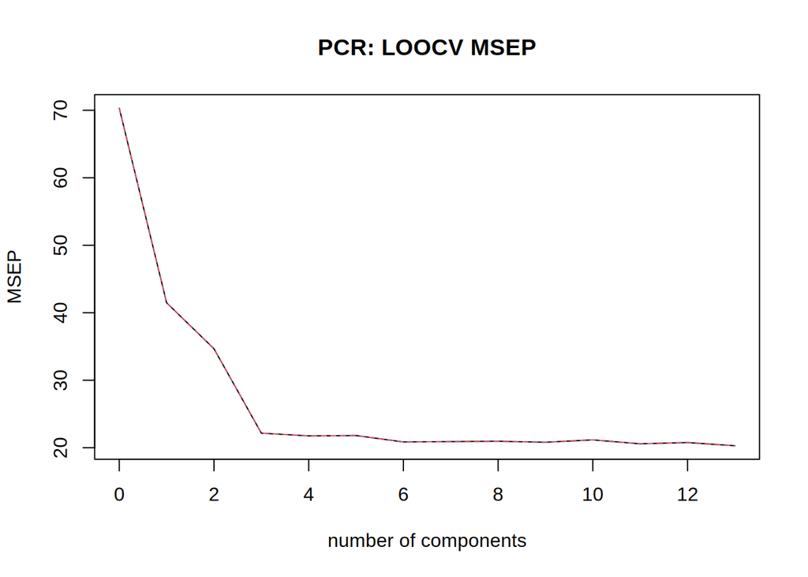

```r
validationplot(pcr_fit, val.type = "MSEP", main = "PCR: LOOCV MSEP")
```

```r
#Partial Least Squares (PLS)
pls_fit <- plsr(Y ~ ., data = data_model, validation = "LOO")
summary(pls_fit)
```

```
## Data:    X dimension: 252 13
##  Y dimension: 252 1
## Fit method: kernelpls
## Number of components considered: 13
##
## VALIDATION: RMSEP
## Cross-validated using 252 leave-one-out segments.
##        (Intercept)  1 comps  2 comps  3 comps  4 comps  5 comps  6 comps
## CV           8.385    6.250    5.565    4.608    4.561    4.533    4.533
## adjCV        8.385    6.249    5.565    4.608    4.561    4.532    4.532
##        7 comps  8 comps  9 comps  10 comps  11 comps  12 comps  13 comps
## CV       4.533    4.532    4.504     4.506     4.506     4.505     4.505
## adjCV    4.532    4.531    4.504     4.506     4.505     4.504     4.504
##
## TRAINING: % variance explained
##    1 comps  2 comps  3 comps  4 comps  5 comps  6 comps  7 comps  8 comps
## X    82.82    95.67    97.63    98.19    98.67    98.93    99.25    99.40
## Y    45.63    57.29    71.34    73.14    73.91    74.30    74.47    74.68
##    9 comps  10 comps  11 comps  12 comps  13 comps
## X    99.49     99.63     99.76     99.86    100.00
## Y    74.84     74.86     74.86     74.86     74.86
```

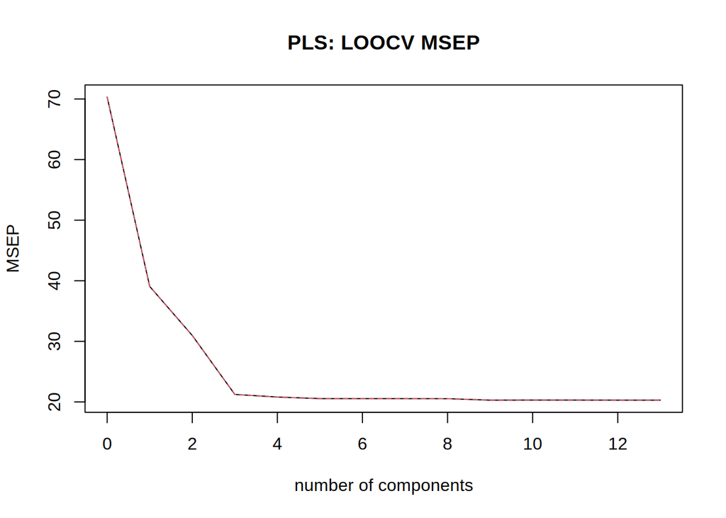

```r
validationplot(pls_fit, val.type = "MSEP", main = "PLS: LOOCV MSEP")
```

It’s time to consider LASSO. We’ll first need to fit the model across a grid of lambda values and then use LOOCV to find the optimal one. Then we’ll fit the LASSO model using the optimal lambda.

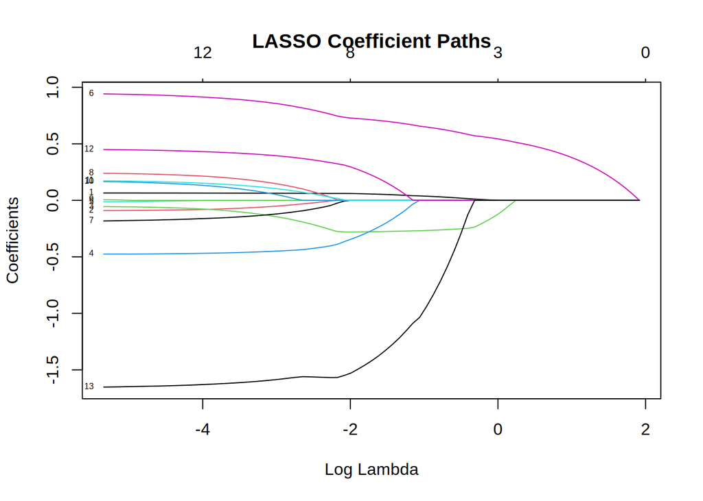

```r
X_matrix <- as.matrix(X)

lasso_fit <- glmnet(X_matrix, Y, alpha = 1)
plot(lasso_fit, xvar = "lambda", label = TRUE, main = "LASSO Coefficient Paths")
```

```r
cv_lasso <- cv.glmnet(X_matrix, Y, alpha = 1, nfolds = nrow(X))
opt_lambda <- cv_lasso$lambda.min
cat("Optimal lambda:", opt_lambda, "\n")
```

```
## Optimal lambda: 0.03381332
```

```r
lasso_final <- glmnet(X_matrix, Y, alpha = 1, lambda = opt_lambda)
cat("Coefficients of the final LASSO model:\n")
```

```
## Coefficients of the final LASSO model:
```

```r
print(coef(lasso_final))
```

```
## 14 x 1 sparse Matrix of class "dgCMatrix"
##                       s0
## (Intercept) -14.31877678
## age           0.06346504
## weight       -0.06715338
## height       -0.10809604
## neck         -0.45633085
## chest         .
## abdomen       0.88615958
## hip          -0.14030402
## thigh         0.18173133
## knee          .
## ankle         0.09298144
## biceps        0.12791946
## forearm       0.41299702
## wrist        -1.60943266
```

In the end, we shall compare the beforementioned models and their performance on our dataset. To make it consistent with previous tasks, we’ll use LOOCV mean squared prediction error (MSEP) as our performance measure.

```r
pcr_rmsep <- RMSEP(pcr_fit)$val[1,1,]
pls_rmsep <- RMSEP(pls_fit)$val[1,1,]

pcr_best_rmsep <- min(pcr_rmsep)
pls_best_rmsep <- min(pls_rmsep)

cat("PCR best RMSEP:", pcr_best_rmsep, "\n")
```

```
## PCR best RMSEP: 4.504971
```

```r
cat("PLS best RMSEP:", pls_best_rmsep, "\n")
```

```
## PLS best RMSEP: 4.504427
```

```r
lasso_best_rmse <- sqrt(min(cv_lasso$cvm))
cat("LASSO best RMSEP:", lasso_best_rmse, "\n")
```

```
## LASSO best RMSEP: 4.488467
```

Based on that, we can conclude that LASSO is the most suitable model for this data.

# Exercise 2

We begin from loading the data from course directory.

```r
www2 = "https://www.mimuw.edu.pl/~noble/courses/MultivariateStatistics/data/carmarks.txt"
carmarks <- read.table(www2, sep = ";", header = TRUE)
head(carmarks)
```

```
##   CARMARK ECONOMY SERVICE VALUE PRICE DESIGN SPORT SAFETY EASYINESS
## 1    A100     3.9     2.8   2.2   4.2    3.0   3.1    2.4       2.8
## 2    BMW3     4.8     1.6   1.9   5.0    2.0   2.5    1.6       2.8
## 3    CiAX     3.0     3.8   3.8   2.7    4.0   4.4    4.0       2.6
## 4    Ferr     5.3     2.9   2.2   5.9    1.7   1.1    3.3       4.3
## 5    FiUn     2.1     3.9   4.0   2.6    4.5   4.4    4.4       2.2
## 6    FoFi     2.3     3.1   3.4   2.6    3.2   3.3    3.6       2.8
```

We now split the dataset. Let the X variables be (price, value) and let the Y variables be (economy, service, design, sport, safety, easyiness).

```r
X <- carmarks[, c("PRICE", "VALUE")]
Y <- carmarks[, c("ECONOMY", "SERVICE", "DESIGN", "SPORT", "SAFETY", "EASYINESS")]
```

Now we can perform canonical correlation analysis.

```r
cca <- cancor(X, Y)
cca
```

```
## $cor
## [1] 0.9791972 0.8851224
##
## $xcoef
##              [,1]       [,2]
## PRICE  0.07105407 -0.3415287
## VALUE -0.12521238 -0.3595609
##
## $ycoef
##                   [,1]         [,2]         [,3]         [,4]         [,5]
## ECONOMY    0.092212427 -0.121092546 -0.254619528 -0.007674089 -0.037102809
## SERVICE   -0.040760051 -0.116024901  0.294153541  0.006626431 -0.730324047
## DESIGN    -0.001012802  0.002515381 -0.477987549 -0.516175123 -0.009069643
## SPORT     -0.097743919  0.020397998  0.013859045  0.438599322 -0.027468582
## SAFETY    -0.047471563  0.003025469  0.006140193 -0.005587635  0.548984934
## EASYINESS -0.080197194 -0.195025111 -0.006808911  0.003643125 -0.015654487
##                 [,6]
## ECONOMY    0.3403942
## SERVICE    0.3285538
## DESIGN    -0.0507337
## SPORT     -0.2562682
## SAFETY     0.2080810
## EASYINESS -0.8114003
##
## $xcenter
##    PRICE    VALUE
## 3.273913 3.152174
##
## $ycenter
##   ECONOMY   SERVICE    DESIGN     SPORT    SAFETY EASYINESS
##  3.291304  3.060870  3.200000  3.465217  3.286957  2.786957
```

We can now use these coefficients to compute and plot the canonical variates.

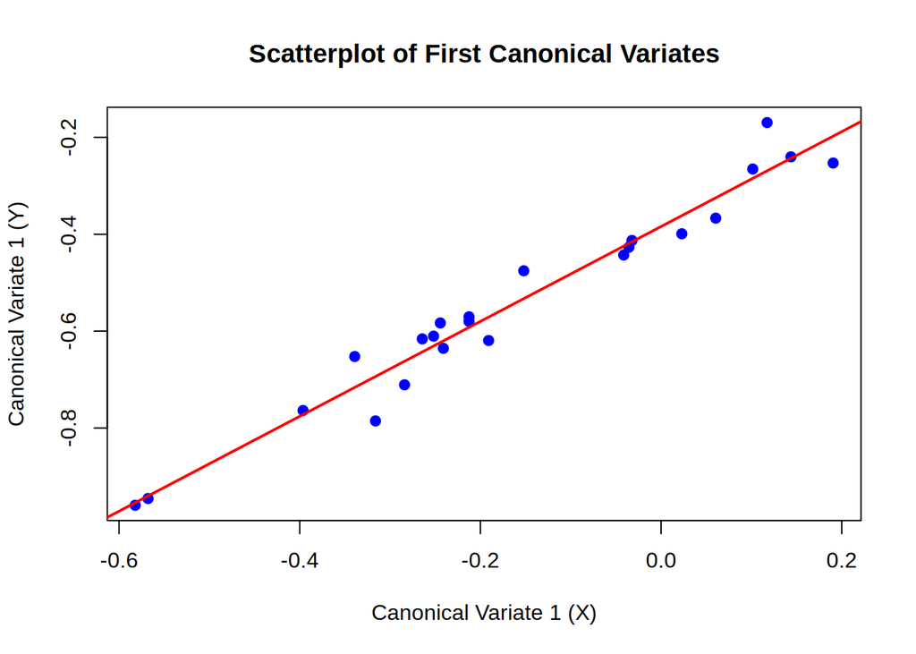

```r
U <- as.matrix(X) %*% cca$xcoef
V <- as.matrix(Y) %*% cca$ycoef

plot(U[,1], V[,1],
     xlab = "Canonical Variate 1 (X)",
     ylab = "Canonical Variate 1 (Y)",
     main = "Scatterplot of First Canonical Variates",
     pch = 19, col = "blue")
abline(lm(V[,1] ~ U[,1]), col = "red", lwd = 2)
```

# Exercise 4

As always, we begin from loading the data.

```r
www4 = "https://www.mimuw.edu.pl/~noble/courses/MultivariateStatistics/data/boston_corrected.txt"
boston <- import(www4)
```

Now we shall spit the data into explanatory and response variables.

```r
boston$log_MEDV <- log(boston$MEDV)
X <- as.matrix(boston[, c("CRIM", "ZN", "INDUS", "CHAS", "NOX", "RM",
                     "AGE", "DIS", "RAD", "TAX", "PTRATIO", "B", "LSTAT")])
Y <- boston$log_MEDV
```

We can perform an OLS regression analysis.

```r
ols_model <- lm(log_MEDV ~ CRIM + ZN + INDUS + CHAS + NOX + RM +
                AGE + DIS + RAD + TAX + PTRATIO + B + LSTAT, data = boston)
summary(ols_model)
```

```
##
## Call:
## lm(formula = log_MEDV ~ CRIM + ZN + INDUS + CHAS + NOX + RM +
##     AGE + DIS + RAD + TAX + PTRATIO + B + LSTAT, data = boston)
##
## Residuals:
##      Min       1Q   Median       3Q      Max
## -0.73361 -0.09747 -0.01657  0.09629  0.86435
##
## Coefficients:
##               Estimate Std. Error t value Pr(>|t|)
## (Intercept)  4.1020423  0.2042726  20.081  < 2e-16 ***
## CRIM        -0.0102715  0.0013155  -7.808 3.52e-14 ***
## ZN           0.0011725  0.0005495   2.134 0.033349 *
## INDUS        0.0024668  0.0024614   1.002 0.316755
## CHAS         0.1008876  0.0344859   2.925 0.003598 **
## NOX         -0.7783993  0.1528902  -5.091 5.07e-07 ***
## RM           0.0908331  0.0167280   5.430 8.87e-08 ***
## AGE          0.0002106  0.0005287   0.398 0.690567
## DIS         -0.0490873  0.0079834  -6.149 1.62e-09 ***
## RAD          0.0142673  0.0026556   5.373 1.20e-07 ***
## TAX         -0.0006258  0.0001505  -4.157 3.80e-05 ***
## PTRATIO     -0.0382715  0.0052365  -7.309 1.10e-12 ***
## B            0.0004136  0.0001075   3.847 0.000135 ***
## LSTAT       -0.0290355  0.0020299 -14.304  < 2e-16 ***
## ---
## Signif. codes:  0 '***' 0.001 '**' 0.01 '*' 0.05 '.' 0.1 ' ' 1
##
## Residual standard error: 0.1899 on 492 degrees of freedom
## Multiple R-squared:  0.7896, Adjusted R-squared:  0.7841
## F-statistic: 142.1 on 13 and 492 DF,  p-value: < 2.2e-16
```

To assess whether the OLS regression is really effective, let’s estimate directly the prediction error of it via leave-one-out cross-validation.

```r
loocv_ols_mse <- mean((ols_model$residuals / (1 - lm.influence(ols_model)$hat))^2)
cat("OLS LOOCV Estimated MSE:", loocv_ols_mse, "\n")
```

```
## OLS LOOCV Estimated MSE: 0.03801705
```

The OLS is indeed effective, based on quite impressive MSE. We should still check whether other methods, such as LASSO regression, give better results.

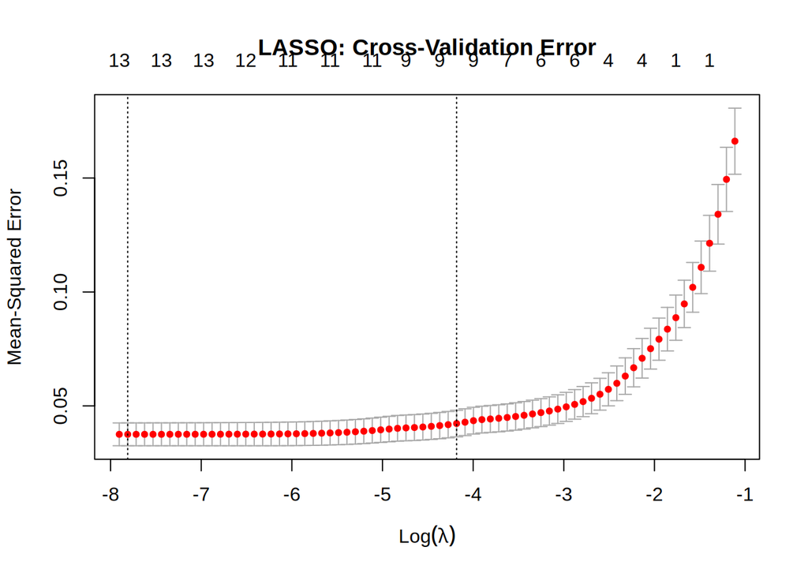

```r
cv_lasso <- cv.glmnet(X, Y, alpha = 1)
plot(cv_lasso, main = "LASSO: Cross-Validation Error")
```

```r
optimal_lambda <- cv_lasso$lambda.min
cat("Optimal lambda (LASSO):", optimal_lambda, "\n")
```

```
## Optimal lambda (LASSO): 0.0004052834
```

```r
lasso_model <- glmnet(X, Y, alpha = 1, lambda = optimal_lambda)
cat("LASSO Coefficients:\n")
```

```
## LASSO Coefficients:
```

```r
print(coef(lasso_model))
```

```
## 14 x 1 sparse Matrix of class "dgCMatrix"
##                        s0
## (Intercept)  4.0697256981
## CRIM        -0.0101347663
## ZN           0.0010830723
## INDUS        0.0018761217
## CHAS         0.1016089715
## NOX         -0.7509078310
## RM           0.0920238770
## AGE          0.0001401822
## DIS         -0.0484410037
## RAD          0.0133437489
## TAX         -0.0005785681
## PTRATIO     -0.0378332227
## B            0.0004095268
## LSTAT       -0.0288844303
```

```r
lasso_cv_mse <- min(cv_lasso$cvm)
cat("LASSO CV MSE:", lasso_cv_mse, "\n")
```

```
## LASSO CV MSE: 0.03752072
```

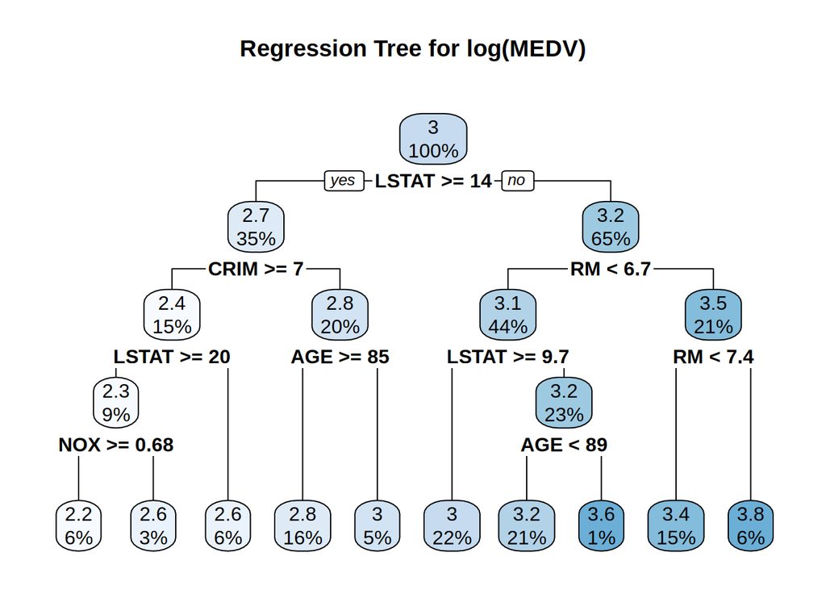

```r
tree_model <- rpart(log_MEDV ~ CRIM + ZN + INDUS + CHAS + NOX + RM +
                      AGE + DIS + RAD + TAX + PTRATIO + B + LSTAT,
                    data = boston, method = "anova")

rpart.plot(tree_model, main = "Regression Tree for log(MEDV)")
```

```r
printcp(tree_model)
```

```
##
## Regression tree:
## rpart(formula = log_MEDV ~ CRIM + ZN + INDUS + CHAS + NOX + RM +
##     AGE + DIS + RAD + TAX + PTRATIO + B + LSTAT, data = boston,
##     method = "anova")
##
## Variables actually used in tree construction:
## [1] AGE   CRIM  LSTAT NOX   RM
##
## Root node error: 84.376/506 = 0.16675
##
## n= 506
##
##          CP nsplit rel error  xerror     xstd
## 1  0.456463      0   1.00000 1.00114 0.074278
## 2  0.158071      1   0.54354 0.56264 0.038375
## 3  0.078595      2   0.38547 0.40844 0.035308
## 4  0.034689      3   0.30687 0.37463 0.032945
## 5  0.022329      4   0.27218 0.34248 0.032677
## 6  0.020436      5   0.24985 0.32784 0.032094
## 7  0.015779      6   0.22942 0.30950 0.030664
## 8  0.012378      7   0.21364 0.28705 0.027058
## 9  0.011366      8   0.20126 0.26635 0.025157
## 10 0.010000      9   0.18989 0.27026 0.025703
```

```r
cat("OLS LOOCV MSE:", loocv_ols_mse, "\n")
```

```
## OLS LOOCV MSE: 0.03801705
```

```r
cat("LASSO CV MSE:", lasso_cv_mse, "\n")
```

```
## LASSO CV MSE: 0.03752072
```

```r
tree_cp <- printcp(tree_model)
```

```
##
## Regression tree:
## rpart(formula = log_MEDV ~ CRIM + ZN + INDUS + CHAS + NOX + RM +
##     AGE + DIS + RAD + TAX + PTRATIO + B + LSTAT, data = boston,
##     method = "anova")
##
## Variables actually used in tree construction:
## [1] AGE   CRIM  LSTAT NOX   RM
##
## Root node error: 84.376/506 = 0.16675
##
## n= 506
##
##          CP nsplit rel error  xerror     xstd
## 1  0.456463      0   1.00000 1.00114 0.074278
## 2  0.158071      1   0.54354 0.56264 0.038375
## 3  0.078595      2   0.38547 0.40844 0.035308
## 4  0.034689      3   0.30687 0.37463 0.032945
## 5  0.022329      4   0.27218 0.34248 0.032677
## 6  0.020436      5   0.24985 0.32784 0.032094
## 7  0.015779      6   0.22942 0.30950 0.030664
## 8  0.012378      7   0.21364 0.28705 0.027058
## 9  0.011366      8   0.20126 0.26635 0.025157
## 10 0.010000      9   0.18989 0.27026 0.025703
```